# **Regularization**

Overfitting is bad for a machine learning model because it gives too much importance to the training data points and tries to fit a curve that passes through all the points. So, we need to reduce the importance given to these exact points and account for some sort of variance as well. This can be done by adding a penalty term to the loss function, discouraging the model from assigning too much importance to individual features or coefficients. This technique is called Regularization.

Regularization is an important technique in machine learning that helps to improve model accuracy by preventing overfitting, which happens when a model learns the training data too well, including noise and outliers, and performs poorly on new data. By adding a penalty for complexity, it helps simpler models perform better on new data.

[figure not shown]

There primarily exist 3 types of regularizations: Lasso (L1), Ridge (L2) and Elastic Net (L1-L2) regularizations. The only difference amongst them is what kind of penalty term is added.

There are several ways of controlling the capacity of Machine Learning models and Neural Networks to prevent overfitting:

### **1. Lasso Regression**

**L1 regularization** is a relatively common form of regularization, where for each weight **w** we add the term  
**λ |w|** to the objective. The L1 regularization has the intriguing property that it leads the weight vectors to become sparse during optimization (i.e., very close to exactly zero). In other words, neurons with L1 regularization end up using only a sparse subset of their most important inputs and become nearly invariant to the “noisy” inputs. In comparison, final weight vectors from L2 regularization are usually diffuse, with small numbers. In practice, if you are not concerned with explicit feature selection, L2 regularization can be expected to give superior performance over L1.

A regression model that uses the **L1 Regularization** technique is called **LASSO (Least Absolute Shrinkage and Selection Operator)** regression. It adds the **absolute value of the magnitude** of the coefficient as a penalty term to the loss function (L).  
This penalty can shrink some coefficients to zero, which helps in selecting only the important features and ignoring the less important ones.

**Cost = (1/n) ∑(i=1 to n) (yᵢ − ŷᵢ)² + λ ∑(i=1 to m) |wᵢ|**

Where:

- *m* - Number of Features
- *n* - Number of Examples
- *yᵢ* - Actual Target Value
- *ŷᵢ* - Predicted Target Value

### **2. Ridge Regression**

A regression model that uses the **L2 regularization** technique is called **Ridge regression**. It adds the **squared magnitude** of the coefficient as a penalty term to the loss function (L).

**Cost = (1/n) ∑(i=1 to n) (yᵢ − ŷᵢ)² + λ ∑(i=1 to m) (wᵢ²)**

Where:

- *n* = Number of examples or data points
- *m* = Number of features i.e., predictor variables
- *yᵢ* = Actual target value for the *iᵗʰ* example
- *ŷᵢ* = Predicted target value for the *iᵗʰ* example
- *wᵢ* = Coefficients of the features
- *λ* = Regularization parameter that controls the strength of regularization

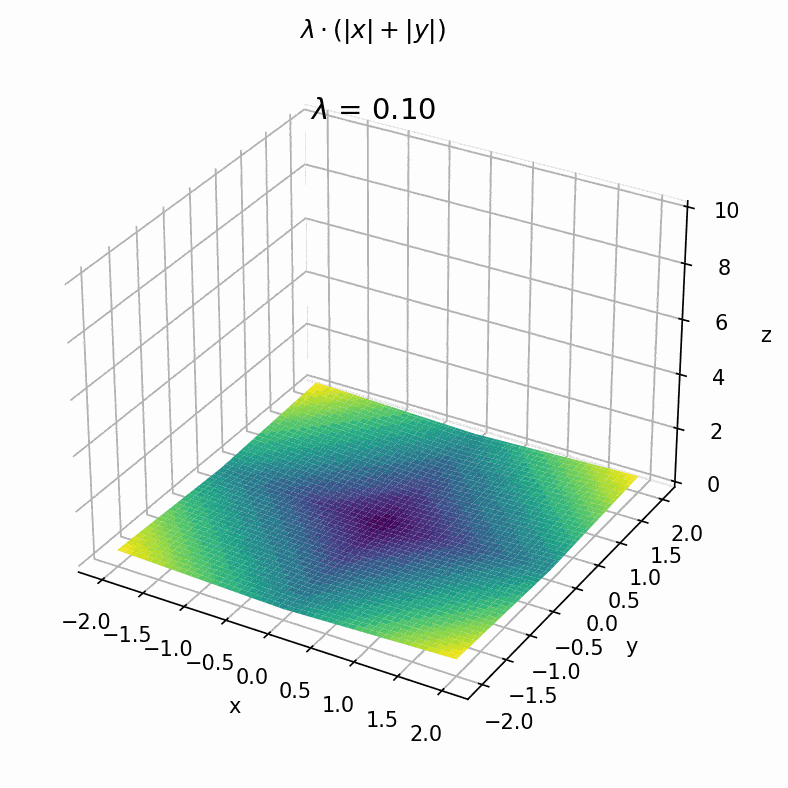

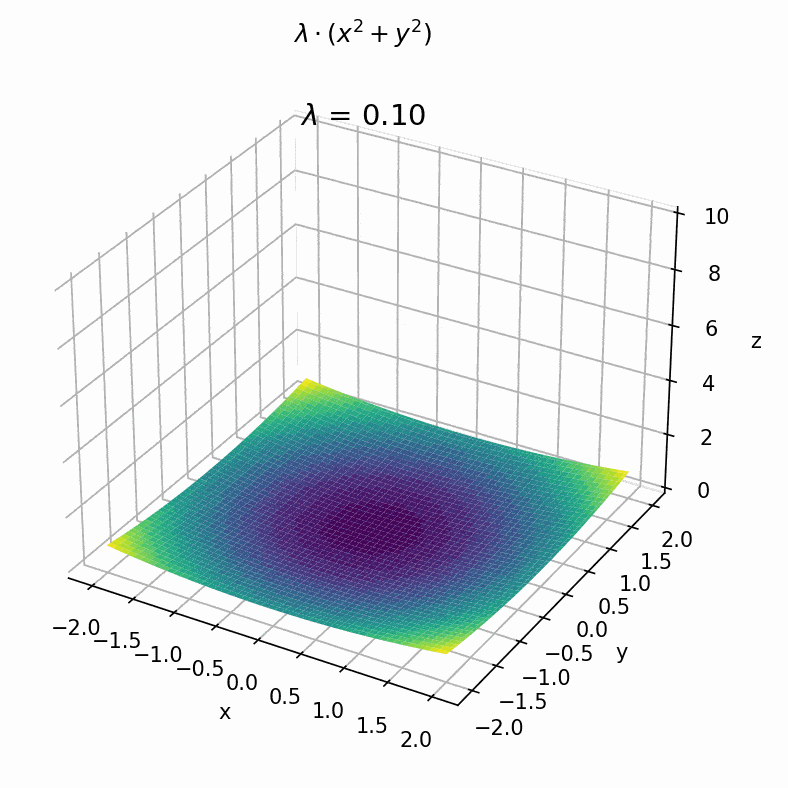

Animation of increasing levels of regularization strength of λ from 0 to 10, showcasing how the penalty surface shapes become increasingly extreme.

### **3. Elastic Net Regression**

It is possible to combine the L1 regularization with the L2 regularization:  
**λ₁ |w| + λ₂w²** (this is called **Elastic net regularization**).

**Elastic Net Regression** is a combination of both **L1 as well as L2 regularization**. That shows that we add the **absolute norm of the weights** as well as the **squared measure of the weights**. With the help of an extra hyperparameter that controls the ratio of the L1 and L2 regularization:

**Cost = (1/n) ∑(i=1 to n) (yᵢ − ŷᵢ)² + λ [ (1 − α) ∑(i=1 to m) |wᵢ| + α ∑(i=1 to m) (wᵢ²) ]**

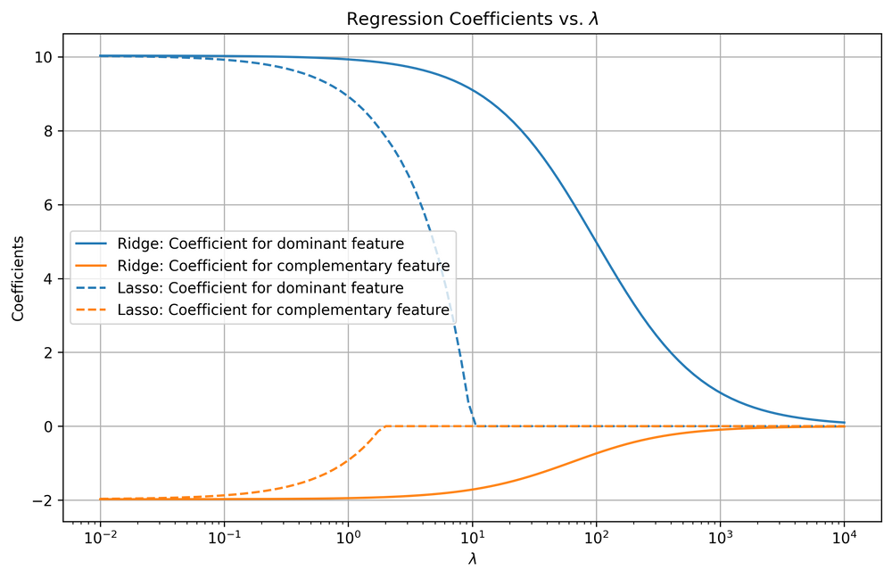

Ridge Regression (solid lines) has an L2 penalty and shrinks coefficients towards 0, but very rarely all the way to 0. Lasso Regression (dashed lines) has an L1 penalty and shrinks coefficients all the way towards 0, resulting in sparser solutions.

**4. Max norm constraints**

Another form of regularization is to enforce an absolute upper bound on the magnitude of the weight vector for every neuron and use projected gradient descent to enforce the constraint. In practice, this corresponds to performing the parameter update as normal, and then enforcing the constraint by clamping the weight vector **w** of every neuron to satisfy **‖w‖₂ < c**. Typical values of **c** are on the order of 3 or 4. Some people report improvements when using this form of regularization. One of its appealing properties is that the network cannot “explode” even when the learning rates are set too high because the updates are always bounded.

**5. Dropout**

**Dropout** is an extremely effective, simple, and recently introduced regularization technique that complements the other methods (L1, L2, maxnorm). While training, dropout is implemented by only keeping a neuron active with some probability **p** (a hyperparameter), or setting it to zero otherwise.

**References:**

https://www.mdrk.io/regularization-in-machine-learning-part1/